# Problema 4 - Checkpoint 3

Diogo Florêncio

# Os dados

Os dados compõe uma amostra de dados da atividade global do github, neles contém a contagem de quantas pessoas editaram arquivos para cada extensão de arquivo no período de 2016 à 2017. Estes dados estão disponíveis [aqui](https://raw.githubusercontent.com/nazareno/fpcc2/master/datasets/github-users-committing-filetypes.csv). Objetivo dessa análise é aprender a aplicar testes de hipótese, interpretar o p-valor e relacionar os resultados de testes de hipótese e ICs.

```r
amostra <- read.csv("../dados/github-users-committing-filetypes.csv")
#formatando data
amostra = amostra %>%
        mutate(date = as.Date(paste(month_day,the_month,the_year),format = "%d %m %Y")) %>%
        mutate(week_day = (weekdays(as.Date(date))))%>%
        select(file_extension, week_day, date, users)
#filtrando dados de interesse
java_2016 = filter(amostra, file_extension == "java",
                          month(date) %in% c("1","2","3","4"),
                          year(date) == "2016")
java_2017 = filter(amostra, file_extension == "java",
                          month(date) %in% c("1","2","3","4"),
                          year(date) == "2017")
```

# Popularidade de Java

O parâmetro utilizado para mensurar a popularidade de `java` foi a quantidade média de edições por ano.

### Intervalo de Confiança

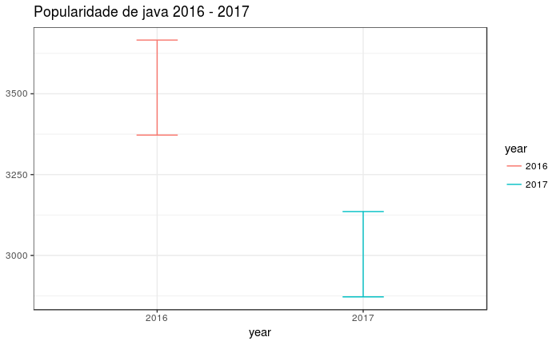

```r
ic_java_2016 =  bootstrap(java_2016, mean(users)) %>%
                    CI.percentile(probs = c(.025, .975)) %>%
                    as.data.frame() %>%
                    mutate(year = "2016")

ic_java_2017 =  bootstrap(java_2017, mean(users)) %>%
                    CI.percentile(probs = c(.025, .975)) %>%
                    as.data.frame() %>%
                    mutate(year = "2017")
data.frame(rbind(ic_java_2016, ic_java_2017)) %>%
  ggplot(aes(x = year, ymin = X2.5., ymax = X97.5., color = year)) +
  geom_errorbar(width = .2)+
  ggtitle("Popularidade de java 2016 - 2017")
```

### Teste de hipótese

Análisando a amostra, agora por teste de hipótese, primeiro calculei a diferença observada nas médias de popularidade em 2016 e 2017.

```r
java = filter(amostra, file_extension == "java") %>%
        group_by(year(date)) %>%
        summarise(media = mean(users))
diff_media_observada = diff(java$media)
diff_media_observada
```

```
[1] -287.4896
```

Para este caso a `hipótese nula - H0` é seguinte situação: *não haver associação nenhuma entre popularidade e ano*. Então analisei o quão frequente seria encontrar uma diferença do mesmo tamanho da observada na amostra considerando `h0`. Caso a diferença observada na amostra aconteça facilmente na hipótese nula, então não há evidência forte de associação: o que observamos acontece também quando não há associação.

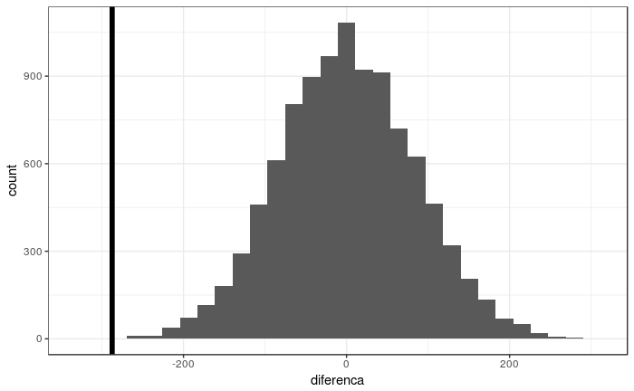

O `p-valor` (também chamado de nível descritivo ou probabilidade de significância), é a probabilidade de se obter uma estatística de teste igual ou mais extrema que aquela observada em uma amostra, sob a hipótese nula. Para este caso seria, a probabilidade de se obter uma diferença maior ou igual a observada na amostra considenrando `H0`. Por meio da distribuição amostral da média de popularidade em `H0`, estimei o p-valor:

```r
oneway_test(users ~ as.factor(year(date)),
            data = rbind(java_2016, java_2017),
            distribution = "exact") %>%
            pvalue()
```

```
[1] 5.498467e-07
```

Avaliando o `p-valor` estimado, a diferença observada na amostra é significativamente improvável na `hipótese nula`, logo `H0` é rejeitada. Com isso pode-se concluir que existe um indicativo de associação entre popularidade e ano; e que a diferença observada é significativa. Entre outras palavras existe um indicativo de que há uma diferença significativa na popularidade de `java` entre 2016 e 2017.

# Comparando os Resultados